# DSC 465, Homework 3

Kefu Zhu

03/24/2019

```r
# Load library
library(wooldridge)
library(MASS)
library(class)
library(ROCR)
library(randomForest)
```

# Question 1

## (a)

**Define**:

- $A:$ abuse == 1
- $B:$ mothalc == 1 and fathalc == 1
- $C:$ mothalc == 0 and fathalc == 0

Then we have

$OR(abuse == 1 | \{\mathrm{mothalc} == 1\ \mathrm{and}\ \mathrm{fathalc} == 1\}; \{\mathrm{mothalc} == 0\ \mathrm{and}\ \mathrm{fathalc} == 0\}) = OR(A|B,C) = \frac{P(A|B)/(1-P(A|B))}{P(A|C)/(1-P(A|C))}$

We know

$P(A|B)/(1-P(A|B)) = \frac{\exp(\beta_0 + \beta_1 + \beta_2)}{1 + \exp(\beta_0 + \beta_1 + \beta_2)} \cdot \frac{1 + \exp(\beta_0 + \beta_1 + \beta_2)}{1} = \exp(\beta_0 + \beta_1 + \beta_2)$

Similarly

$P(A|C)/(1-P(A|C)) = \frac{\exp(\beta_0)}{1 + \exp(\beta_0)} \cdot \frac{1 + \exp(\beta_0)}{1} = \exp(\beta_0)$

$\therefore OR(abuse == 1\ |\ \{\mathrm{mothalc} == 1\ \mathrm{and}\ \mathrm{fathalc} == 1\}; \{\mathrm{mothalc} == 0\ \mathrm{and}\ \mathrm{fathalc} == 0\}) = \frac{\exp(\beta_0 + \beta_1 + \beta_2)}{\exp(\beta_0)} = \exp(\beta_1 + \beta_2)$

We also know that

- $OR(\mathrm{abuse} == 1\ |\ \mathrm{mothalc} == 1) = \frac{\exp(\beta_0 + \beta_1 + \beta_2X_2)}{\exp(\beta_0 + \beta_2X_2)} = \exp(\beta_1)$
- $OR(\mathrm{abuse} == 1\ |\ \mathrm{fathalc} == 1) = \frac{\exp(\beta_0 + \beta_1X_1 + \beta_2)}{\exp(\beta_0 + \beta_1X_1)} = \exp(\beta_2)$

$\because \exp(\beta_1 + \beta_2) = \exp(\beta_1) \times \exp(\beta_2)$

$\therefore OR(abuse == 1\ |\ \{\mathrm{mothalc} == 1\ \mathrm{and}\ \mathrm{fathalc} == 1\}; \{\mathrm{mothalc} == 0\ \mathrm{and}\ \mathrm{fathalc} == 0\}) = OR(\mathrm{abuse} == 1\ |\ \mathrm{mothalc} == 1) \times OR(\mathrm{abuse} == 1\ |\ \mathrm{fathalc} == 1)$

## (b)

We know

$OR(abuse == 1\ |\ \{\mathrm{mothalc} == 1\ \mathrm{or}\ \mathrm{fathalc} == 1\}; \{\mathrm{mothalc} == 0\ \mathrm{and}\ \mathrm{fathalc} == 0\}) = e^{0.63}$

which is equivalent to

- $OR(abuse == 1\ |\ \{\mathrm{mothalc} == 1\ \mathrm{and}\ \mathrm{fathalc} == 0\}; \{\mathrm{mothalc} == 0\ \mathrm{and}\ \mathrm{fathalc} == 0\}) = e^{0.63}$
- $OR(abuse == 1\ |\ \{\mathrm{mothalc} == 0\ \mathrm{and}\ \mathrm{fathalc} == 1\}; \{\mathrm{mothalc} == 0\ \mathrm{and}\ \mathrm{fathalc} == 0\}) = e^{0.63}$
- $OR(abuse == 1\ |\ \{\mathrm{mothalc} == 1\ \mathrm{and}\ \mathrm{fathalc} == 1\}; \{\mathrm{mothalc} == 0\ \mathrm{and}\ \mathrm{fathalc} == 0\}) = e^{0.63}$

Similar to the computation in part (a), we can derive that

- $OR(abuse == 1\ |\ \{\mathrm{mothalc} == 1\ \mathrm{and}\ \mathrm{fathalc} == 0\}; \{\mathrm{mothalc} == 0\ \mathrm{and}\ \mathrm{fathalc} == 0\}) = e^{0.63} \Rightarrow \exp(\beta_1) = e^{0.63}$
- $OR(abuse == 1\ |\ \{\mathrm{mothalc} == 0\ \mathrm{and}\ \mathrm{fathalc} == 1\}; \{\mathrm{mothalc} == 0\ \mathrm{and}\ \mathrm{fathalc} == 0\}) = e^{0.63} \Rightarrow \exp(\beta_2) = e^{0.63}$
- $OR(abuse == 1\ |\ \{\mathrm{mothalc} == 1\ \mathrm{and}\ \mathrm{fathalc} == 1\}; \{\mathrm{mothalc} == 0\ \mathrm{and}\ \mathrm{fathalc} == 0\}) = e^{0.63} \Rightarrow \exp(\beta_1 + \beta_2 + \beta_3) = e^{0.63}$

To summarize, we have $\begin{cases} \beta_1 = 0.63 \\ \beta_2 = 0.63 \\ \beta_1 + \beta_2 + \beta_3 = 0.63 \end{cases} \Rightarrow \begin{cases} \beta_1 = 0.63 \\ \beta_2 = 0.63 \\ \beta_3 = -0.63 \end{cases}$

## (c)

```r
model_1 = glm(abuse ~ mothalc + fathalc, family = 'binomial', data = alcohol)
summary(model_1)
```

```
##
## Call:
## glm(formula = abuse ~ mothalc + fathalc, family = "binomial",
##     data = alcohol)
##
## Deviance Residuals:
##     Min       1Q   Median       3Q      Max
## -0.6552  -0.4333  -0.4333  -0.4333   2.1965
##
## Coefficients:
##             Estimate Std. Error z value Pr(>|z|)
## (Intercept) -2.31832    0.03862 -60.024  < 2e-16 ***
## mothalc      0.38506    0.14613   2.635  0.00841 **
## fathalc      0.50390    0.08347   6.037 1.57e-09 ***
## ---
## Signif. codes:  0 '***' 0.001 '**' 0.01 '*' 0.05 '.' 0.1 ' ' 1
##
## (Dispersion parameter for binomial family taken to be 1)
##
##     Null deviance: 6349.8  on 9821  degrees of freedom
## Residual deviance: 6303.8  on 9819  degrees of freedom
## AIC: 6309.8
##
## Number of Fisher Scoring iterations: 5
```

```r
model_3 = glm(abuse ~ mothalc * fathalc, family = 'binomial', data = alcohol)
summary(model_3)
```

```
##
## Call:
## glm(formula = abuse ~ mothalc * fathalc, family = "binomial",
##     data = alcohol)
##
## Deviance Residuals:
##     Min       1Q   Median       3Q      Max
## -0.6518  -0.4332  -0.4332  -0.4332   2.1966
##
## Coefficients:
##                 Estimate Std. Error z value Pr(>|z|)
## (Intercept)     -2.31877    0.03898 -59.491  < 2e-16 ***
## mothalc          0.39696    0.19933   1.992   0.0464 *
## fathalc          0.50618    0.08742   5.791 7.02e-09 ***
## mothalc:fathalc -0.02558    0.29282  -0.087   0.9304
## ---
## Signif. codes:  0 '***' 0.001 '**' 0.01 '*' 0.05 '.' 0.1 ' ' 1
##
## (Dispersion parameter for binomial family taken to be 1)
##
##     Null deviance: 6349.8  on 9821  degrees of freedom
## Residual deviance: 6303.8  on 9818  degrees of freedom
## AIC: 6311.8
##
## Number of Fisher Scoring iterations: 5
```

### (i)

```r
odds_ratio = exp(cbind(coef(model_1), confint(model_1))[-1,])
odds_ratio
```

```
##                     2.5 %   97.5 %
## mothalc 1.469709 1.094483 1.942587
## fathalc 1.655165 1.402833 1.946095
```

**Answer**:

For model (1), the odds ratio

- **OR(abuse == 1 | mothalc == 1)** is 1.4697085 with 95% confidence interval, (1.0944832, 1.9425872)
- **OR(abuse == 1 | fathalc == 1)** is 1.6551649 with 95% confidence interval, (1.4028329, 1.9460949)

### (ii)

```r
confint(model_3)
```

```
##                       2.5 %     97.5 %
## (Intercept)     -2.39597918 -2.2431688
## mothalc         -0.01264573  0.7714480
## fathalc          0.33265495  0.6754953
## mothalc:fathalc -0.60032434  0.5511085
```

**Answer**:

Since the 95% confidence interval of $\beta_3$ does contain zero, there isn’t strong evidence of $\beta_3 \ne 0$ in model (3).

The conclusion is consistent with equation (2) which states that odds ratio, $OR(\mathrm{abuse} == 1\ |\ \mathrm{mothalc} == 1)$, does not depend on the value of `fathalc`

# Question 2

## (a)

**Define**:

$\begin{cases} P_A[i]\ is\ the\ ith\ element\ in\ vector\ P_A \\ P_F[j]\ is\ the\ jth\ element\ in\ vector\ P_F \end{cases}$

For equation $Odds(\mathrm{Document\ is\ Authentic}\ |\ X) = LR \times Odds(\mathrm{Document\ is\ Authentic})$

$\because LR = \frac{P(X\ |\ \mathrm{Document\ is\ Authentic})}{P(X\ |\ \mathrm{Document\ is\ Forged})} = \frac{(P_A[1])^{n_1}(P_A[2])^{n_5}(P_A[3])^{n_9}}{(P_F[1])^{n_1}(P_F[2])^{n_5}(P_F[3])^{n_9}} = \frac{(P_A[1])^{n_1}(P_A[2])^{n_5}(P_A[3])^{n_9}}{(P_F[1])^n}$

$\because Odds(\mathrm{Document\ is\ Authentic}) = \frac{\pi_A}{1-\pi_A}$

$\therefore Odds(\mathrm{Document\ is\ Authentic}\ |\ X) = \frac{(P_A[1])^{n_1}(P_A[2])^{n_5}(P_A[3])^{n_9}}{(P_F[1])^n} \cdot \frac{\pi_A}{1-\pi_A}$

## (b)

To predict an accounting document is authentic, we must have $Odds(\mathrm{Document\ is\ Authentic}\ |\ X) \ge 1$

$\therefore$

$\frac{(P_A[1])^{n_1}(P_A[2])^{n_5}(P_A[3])^{n_9}}{(P_F[1])^n} \cdot \pi_A \ge 1$

$(P_A[1])^{n_1}(P_A[2])^{n_5}(P_A[3])^{n_9} \cdot \pi_A \ge (P_F[1])^n$

$n_1log(P_A[1]) + n_5log(P_A[2]) + n_9log(P_A[3]) + log(\pi_A) \ge nlog(P_F[1])$

$n_1log(P_A[1]) + n_5log(P_A[2]) + n_9log(P_A[3]) + log(\pi_A) - nlog(P_F[1]) \ge 0$

If we denote this formula as $a \times n_1 + b \times n_5 + c \times n_9 + d \ge 0$, then

- $a = log(P_A[1])$
- $b = log(P_A[2])$
- $c = log(P_A[3])$
- $d = log(\pi_A) - nlog(P_F[1])$

## (c)

**Define**

- $A$: The document is authentic
- $F$: The document is forged
- $X$: Observed frequencies $X = (n_1, n_5, n_9)$ of the leading digits that are ‘$1$’, ‘$5$’ or ‘$9$’

We know the posterior probability is calculated as

$P(F|X) = \frac{P(X|F)}{P(X|F)P(F) + P(X|A)P(A)} \cdot P(F)$

where $P(F|X)$ is the **posterior probability**, $\frac{P(X|F)}{P(X|F)P(F) + P(X|A)P(A)}$ is the **likelihood**, $P(F)$ is the prior

```r
# Parameters
P_A = c(0.3/(0.3 + 0.071 + 0.046),0.071/(0.3 + 0.071 + 0.046),0.046/(0.3 + 0.071 + 0.046))
P_F = c(1/3,1/3,1/3)
n1 = 7
n5 = 5
n9 = 8
prior = 1/2
```

```r
X_F = choose(20, 7) * choose(13, 5) * (P_F[1]) ^ 20
X_F
```

```
## [1] 0.02861325
```

$P(X|F) = {20 \choose 7}(\frac{1}{3})^7 \cdot {13 \choose 5}(\frac{1}{3})^5 \cdot {8 \choose 8}(\frac{1}{3})^8 = {20 \choose 7}{13 \choose 5}(\frac{1}{3})^{20} =$ 0.0286133

```r
X_A = choose(20, 7) * (P_A[1] ^ n1) * choose(13, 5) * (P_A[2] ^ n5) * 1 * (P_A[3] ^ n9)
X_A
```

```
## [1] 3.122298e-05
```

$P(X|A) = {20 \choose 7}(P_A[1])^{n_1} \cdot {13 \choose 5}(P_A[2])^{n_5} \cdot {8 \choose 8}(P_A[3])^{n_5} =$ 3.122298310^{-5}

```r
posterior = (X_F)/(X_F * prior + X_A * (1-prior)) * prior
posterior
```

```
## [1] 0.99891
```

Therefore, $P(F|X) = \frac{P(X|F)}{P(X|F)P(F) + P(X|A)P(A)} \cdot P(F) =$ 0.99891

**Answer**:

Given evidence $X$, the posterior probability that the document is forged is 0.99891

# Question 3

## (a)

```r
# Combine the dataset
Pima.all = rbind(Pima.tr, Pima.te)
```

### npreg vs. type

```r
wilcox.test(npreg ~ type, data = Pima.all)
```

```
##
##  Wilcoxon rank sum test with continuity correction
##
## data:  npreg by type
## W = 23711, p-value = 3.207e-06
## alternative hypothesis: true location shift is not equal to 0
```

### glu vs. type

```r
wilcox.test(glu ~ type, data = Pima.all)
```

```
##
##  Wilcoxon rank sum test with continuity correction
##
## data:  glu by type
## W = 12946, p-value < 2.2e-16
## alternative hypothesis: true location shift is not equal to 0
```

### bp vs. type

```r
wilcox.test(bp ~ type, data = Pima.all)
```

```
##
##  Wilcoxon rank sum test with continuity correction
##
## data:  bp by type
## W = 24058, p-value = 1.028e-05
## alternative hypothesis: true location shift is not equal to 0
```

### skin vs. type

```r
wilcox.test(skin ~ type, data = Pima.all)
```

```
##
##  Wilcoxon rank sum test with continuity correction
##
## data:  skin by type
## W = 21436, p-value = 2.269e-09
## alternative hypothesis: true location shift is not equal to 0
```

### bmi vs. type

```r
wilcox.test(bmi ~ type, data = Pima.all)
```

```
##
##  Wilcoxon rank sum test with continuity correction
##
## data:  bmi by type
## W = 20052, p-value = 1.026e-11
## alternative hypothesis: true location shift is not equal to 0
```

### ped vs. type

```r
wilcox.test(ped ~ type, data = Pima.all)
```

```
##
##  Wilcoxon rank sum test with continuity correction
##
## data:  ped by type
## W = 22426, p-value = 7.383e-08
## alternative hypothesis: true location shift is not equal to 0
```

### age vs. type

```r
wilcox.test(age ~ type, data = Pima.all)
```

```
##
##  Wilcoxon rank sum test with continuity correction
##
## data:  age by type
## W = 17358, p-value < 2.2e-16
## alternative hypothesis: true location shift is not equal to 0
```

**Answer**:

The p-values for each Wilcoxon rank sum test are summarized below:

- `npreg vs. type`: 3.206848210^{-6}
- `glu vs. type`: 2.010717810^{-28}
- `bp vs. type`: 1.027757310^{-5}
- `skin vs. type`: 2.269302910^{-9}
- `bmi vs. type`: 1.025884210^{-11}
- `ped vs. type`: 7.382619810^{-8}
- `age vs. type`: 3.457370910^{-17}

Since all p-vlaues are smaller than 0.05, which indicates that the distribution of every feature differs significantly between diabetes groups (positive/negative).

Hence, it is recommended to build the model using all seven features

## (b)

```r
# Preparation before log transformation: Make a copy of Pima.all
log_Pima.all = Pima.all
# Add one to npreg to avoid evalutaion of log(0)
log_Pima.all$npreg = log_Pima.all$npreg + 1
# Standardize the first seven features using log transformation (exclude the 8 column, response)
log_Pima.all[,-8] = log(log_Pima.all[,-8])
```

## (c)

```r
evaluation = function(confusion_matrix){
  # Classification error
  CE = (confusion_matrix[1,2] + confusion_matrix[2,1])/sum(confusion_matrix)
  # Sensitivity
  sens = (confusion_matrix[2,2])/sum(confusion_matrix[,2])
  # Specificity
  spec = (confusion_matrix[1,1])/sum(confusion_matrix[,1])

  eval = c(CE,sens,spec)
  names(eval) = c('CE','sens','spec')
  return(eval)
}
```

## (d)

```r
LDA.fit = lda(type ~ ., data = log_Pima.all, CV = TRUE)
QDA.fit = qda(type ~ ., data = log_Pima.all, CV = TRUE)
```

```r
# Initialize the best classification error to 1
best_CE = 1
best_K = -999
KNN.fit = NULL
# Experiment KNN using different values of k (1,3,5,...,35)
for(i in seq(1,35,2)){
  # Fit the KNN model
  knn.fit = knn.cv(train = log_Pima.all[,-8], cl = log_Pima.all$type, k = i)
  # Compute the CE (classification error)
  CE = evaluation(table(knn.fit, log_Pima.all$type))[1]
  # Record the best model based on value of CE
  if(CE < best_CE){
    best_CE = CE
    best_K = i
    KNN.fit = knn.fit
  }
}
```

**Note**: When $K =$ 25, KNN produces the smallest classification error

### (i)

**Answer**:

All of them are using Leave-one-out cross validation

### (ii)

#### LDA

```r
LDA_eval = evaluation(table(LDA.fit$class, log_Pima.all$type))
LDA_eval
```

```
##        CE      sens      spec
## 0.2274436 0.5988701 0.8591549
```

#### QDA

```r
QDA_eval = evaluation(table(QDA.fit$class, log_Pima.all$type))
QDA_eval
```

```
##        CE      sens      spec
## 0.2312030 0.6045198 0.8507042
```

#### KNN

```r
KNN_eval = evaluation(table(KNN.fit, log_Pima.all$type))
KNN_eval
```

```
##        CE      sens      spec
## 0.2500000 0.4576271 0.8957746
```

**Answer**:

No. There isn’t one classifier that outperforms the rest with respect to all summary statistics (CE, sens, spec)

## (e)

### (i)

```r
LR.fit = glm(type ~ ., family = 'binomial', data = log_Pima.all)
```

### (ii)

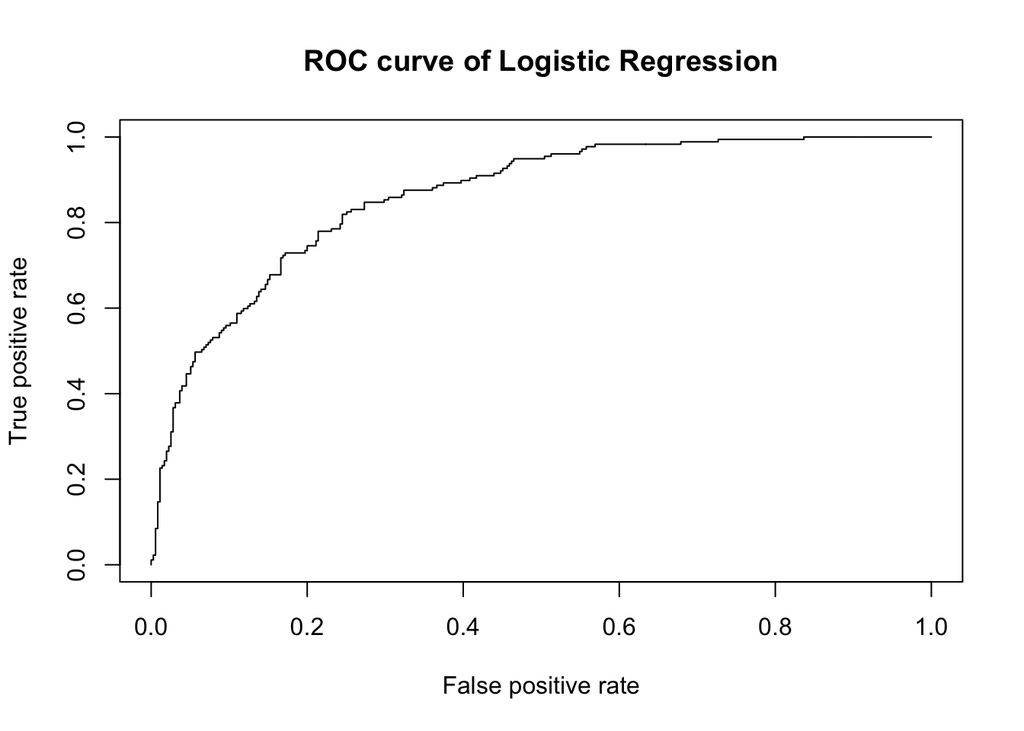

```r
LR.p = predict(LR.fit, log_Pima.all, type = 'response')
LR.pred = prediction(LR.p, log_Pima.all$type)
LR.perf = performance(LR.pred, 'tpr','fpr')
plot(LR.perf, main = 'ROC curve of Logistic Regression')
```

### (iii)

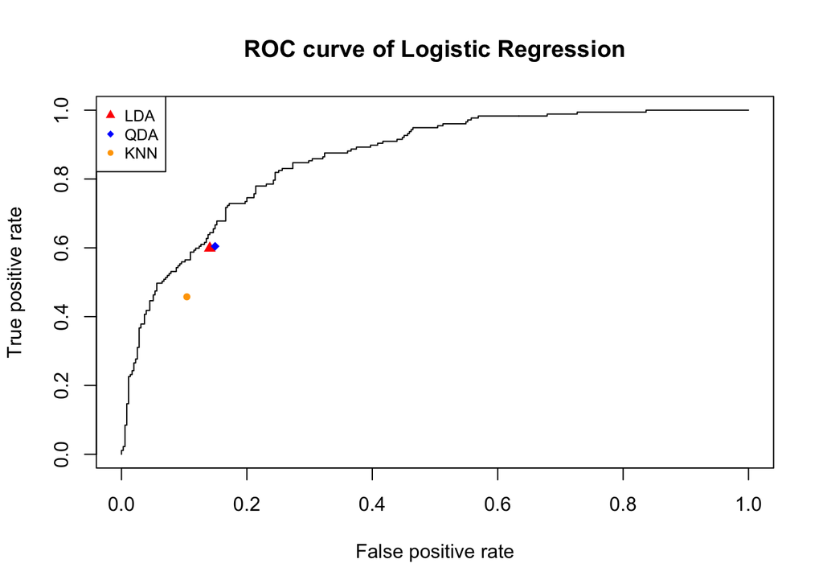

```r
plot(LR.perf, main = 'ROC curve of Logistic Regression')
points(1-LDA_eval[3],LDA_eval[2],col='red',pch=17)
points(1-QDA_eval[3],QDA_eval[2],col='blue',pch=18)
points(1-KNN_eval[3],KNN_eval[2],col='orange',pch=20)
legend('topleft',
        legend = c("LDA", "QDA", 'KNN'),
        col = c('red', 'blue', 'orange'),
        pch = c(17,18,20),
        cex = 0.8)
```

**Answer**:

When classifiers give very different balances between sensitivity and specificity, we look at the area under curve (AUC). The model with higher AUC has better performance.

### (iv)

```r
# Initialize the empty vector to store sensitivity and specificity
LDA_sens = c()
LDA_spec = c()
QDA_sens = c()
QDA_spec = c()
# Experiment LDA and QDA using different prior probability (0,0.01,0.02,...,1)
for(p in seq(0,1,0.01)){
  # Fit the LDA model
  lda.fit = lda(type ~ ., data = log_Pima.all, prior = c(1-p,p), CV = TRUE)
  # Fit the QDA model
  qda.fit = qda(type ~ ., data = log_Pima.all, prior = c(1-p,p), CV = TRUE)
  # Compute the sensitivity for LDA and add it into the vector
  LDA_sens = c(LDA_sens, evaluation(table(lda.fit$class, log_Pima.all$type))[2])
  # Compute the specificity for LDA and add it into the vector
  LDA_spec = c(LDA_spec, evaluation(table(lda.fit$class, log_Pima.all$type))[3])
  # Compute the sensitivity for QDA and add it into the vector
  QDA_sens = c(QDA_sens, evaluation(table(qda.fit$class, log_Pima.all$type))[2])
  # Compute the specificity for QDA and add it into the vector
  QDA_spec = c(QDA_spec, evaluation(table(qda.fit$class, log_Pima.all$type))[3])
}
```

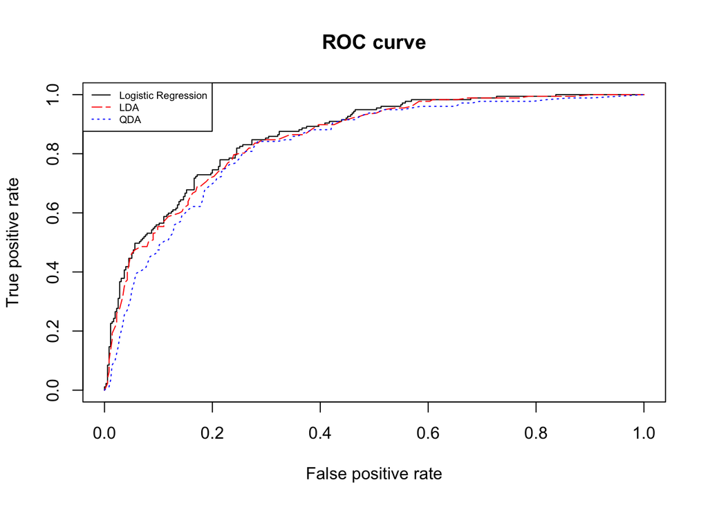

```r
# ROC curve of Logistic Regression
plot(LR.perf, main = 'ROC curve')
# Add ROC curve of LDA
lines(cbind(1-LDA_spec,LDA_sens), col = 'red', lty = 5)
# Add ROC curve of QDA
lines(cbind(1-QDA_spec,QDA_sens), col = 'blue', lty = 3)
legend('topleft',
        legend = c("Logistic Regression","LDA", "QDA"),
        col = c('black','red', 'blue'),
        lty = c(1,5,3),
        cex = 0.6)
```

**Answer**:

From the ROC curves, LDA is more preferable than QDA since its ROC curve is above that of QDA, which means LDA has higher AUC (Area Undr Curve) value.

# Question 4

## (a)

```r
RF.fit = randomForest(type ~ ., data=log_Pima.all)
RF.p = predict(RF.fit, type='prob')
RF.pred = prediction(RF.p[,2], log_Pima.all$type)
RF.perf = performance(RF.pred, 'tpr','fpr')
```

## (b)

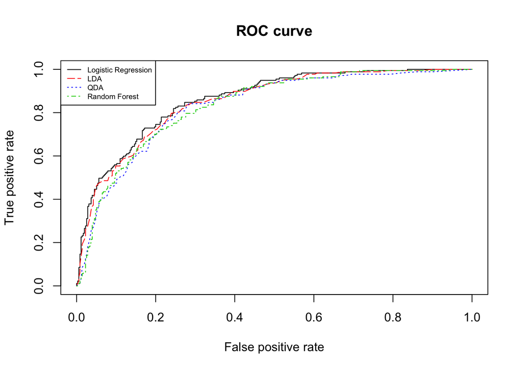

```r
# ROC curve of Logistic Regression
plot(LR.perf, main = 'ROC curve')
# Add ROC curve of LDA
lines(cbind(1-LDA_spec,LDA_sens), col = 'red', lty = 5)
# Add ROC curve of QDA
lines(cbind(1-QDA_spec,QDA_sens), col = 'blue', lty = 3)
# Add ROC curve of Random Forest
lines(cbind(unlist(RF.perf@x.values), unlist(RF.perf@y.values)), col = 'green3', lty = 4)
legend('topleft',
        legend = c("Logistic Regression","LDA", "QDA", "Random Forest"),
        col = c('black','red', 'blue', 'green3'),
        lty = c(1,5,3,4),
        cex = 0.6)
```

**Answer**:

Based on the ROC curve, LDA still seems to outperforms the other models (QDA and RandomForest). And the random forest model does not seem to offer any advantage in this case.

We can also check their exact AUC score from below

```r
# Extract the posterior probability for type == 'Yes' for LDA and QDA
LDA.pred = prediction(LDA.fit$posterior[,2], log_Pima.all$type)
QDA.pred = prediction(QDA.fit$posterior[,2], log_Pima.all$type)
# LR.pred = prediction(predict(LR.fit, log_Pima.all, type = 'response'), log_Pima.all$type)
# Compute the AUC score for Logistic Regression, LDA, QDA and RandomForest
# LR.auc = unlist(performance(LR.pred, measure = 'auc')@y.values)
RF.auc = unlist(performance(RF.pred, measure = 'auc')@y.values)
LDA.auc = unlist(performance(LDA.pred, measure = 'auc')@y.values)
QDA.auc = unlist(performance(QDA.pred, measure = 'auc')@y.values)

# auc_list = c(LR.auc, LDA.auc, QDA.auc, RF.auc)
# names(auc_list) = c('LR','LDA','QDA','RandomForest')

auc_list = c(LDA.auc, QDA.auc, RF.auc)
names(auc_list) = c('LDA','QDA','RandomForest')

auc_list
```

```
##          LDA          QDA RandomForest
##    0.8512453    0.8300629    0.8330946
```